# Assignment6

crator-creator/20162306임유석

2021 5 30

## **Sentiment Analysis on Twitter Dataset**

```r
# 사용할 패키지 추가
library(wordcloud)
library(tm)
library(SnowballC)
library(caret)
library(nnet)
library(randomForest)
library(vip)
library(e1071)
library(pROC)
library(ROCR)
```

### 1. 모델을 수립하기 전에 데이터의 특성을 분석한다. 시각화 도구를 적절히 활용하자.

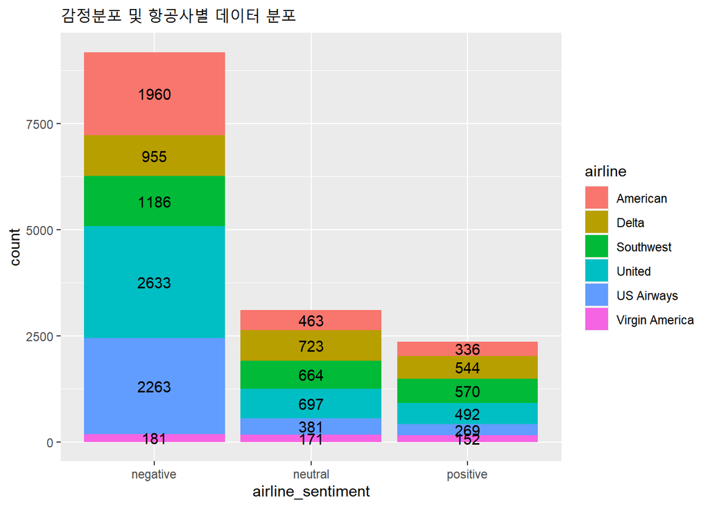

```r
data = read.csv("./data/Tweets_win.csv", stringsAsFactors = FALSE)
#감정 분포 및 항공사별 데이터 분포 확인
ggplot(data,aes(x=airline_sentiment,fill=airline))+geom_bar()+geom_text(aes(label=..count..),stat='count',position=position_stack(0.5))+labs(title="감정분포 및 항공사별 데이터 분포")
```

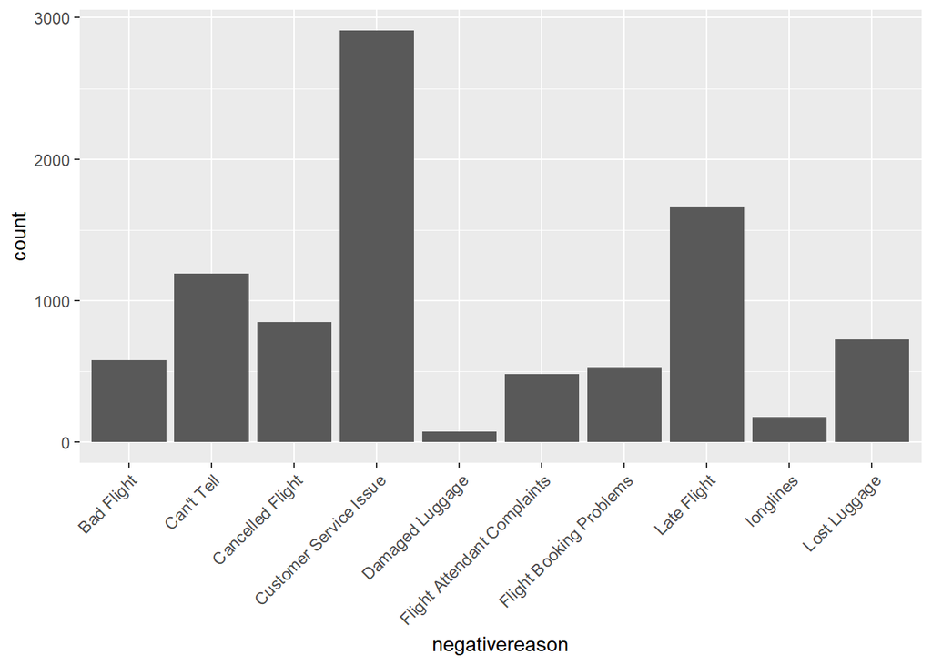

```r
#negative 라벨이 붙은 이유 시각화
data2 = data[data$negativereason != "",]
ggplot(data2,aes(x=negativereason))+geom_bar()+theme(axis.text.x=element_text(size=9, angle=45, hjust=1))
```

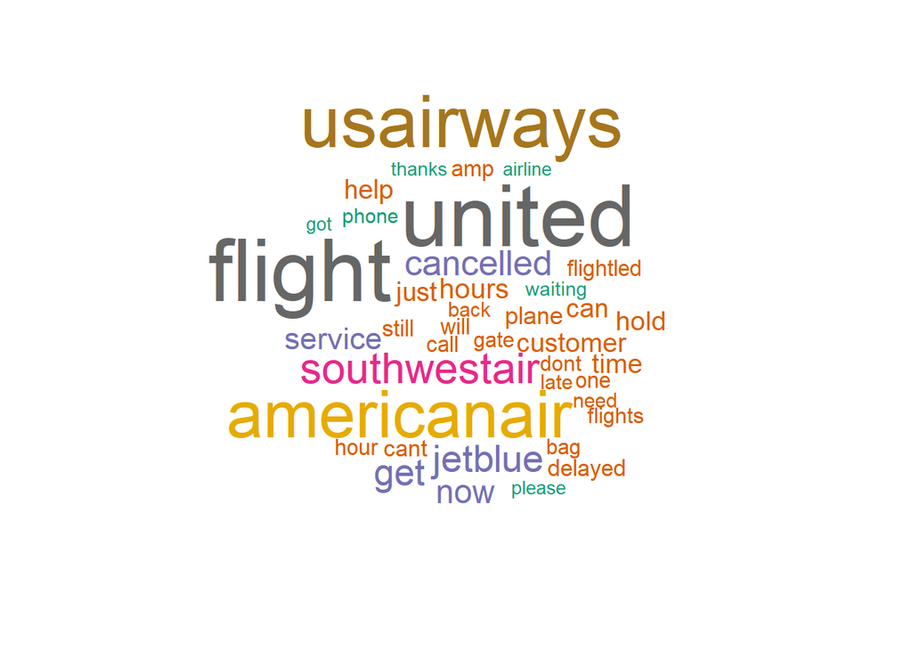

```r
#wordcloud
negative = subset(data, airline_sentiment =="negative")
positive = subset(data, airline_sentiment =="positive")
neutral = subset(data, airline_sentiment =="neutral")
wordcloud(negative$text, max.words = 40, colors=brewer.pal(8,"Dark2"))
```

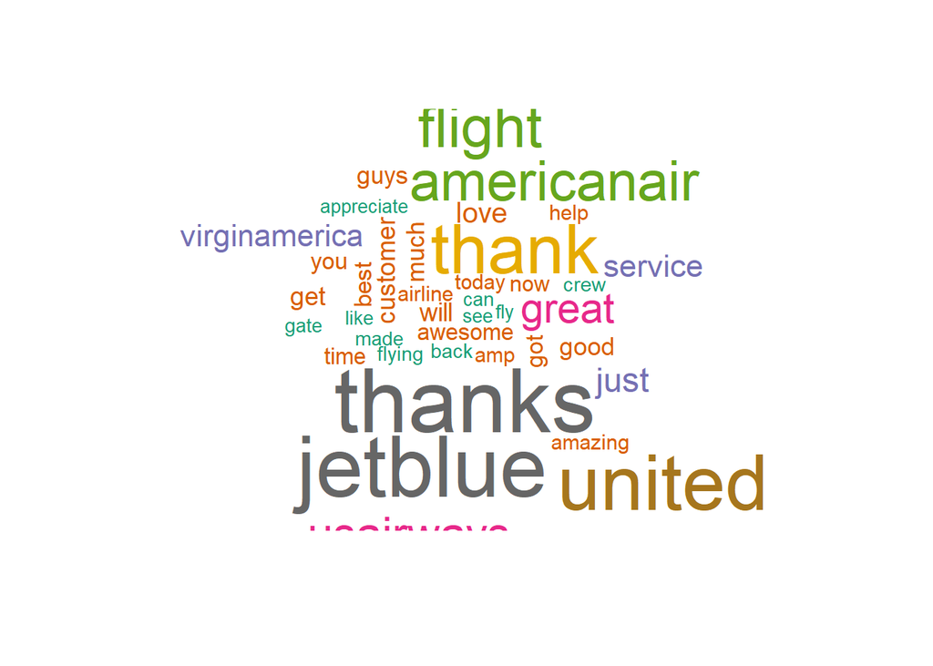

```r
wordcloud(positive$text, max.words = 40, colors=brewer.pal(8,"Dark2"))
```

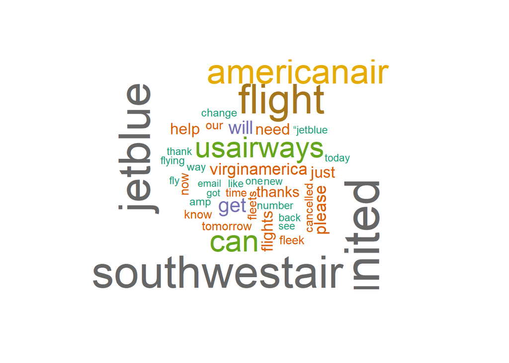

```r
wordcloud(neutral$text, max.words = 40, colors=brewer.pal(8,"Dark2"))
```

### 2. 텍스트 데이터에 bag-of-words 기법을 적용하기 위해 적절한 preprocessing을수행하고, 그 결과를 분석해보자

```r
data$airline_sentiment = factor(data$airline_sentiment)
#corpus화
sent_corpus = VCorpus(VectorSource(data$text))
#대문자 소문자로 변환
sent_corpus_clean = tm_map(sent_corpus, content_transformer(tolower))
#숫자제거
sent_corpus_clean = tm_map(sent_corpus_clean, removeNumbers)
#stopwords 제거
sent_corpus_clean = tm_map(sent_corpus_clean, removeWords, stopwords())
#부호제거
sent_corpus_clean <- tm_map(sent_corpus_clean, removePunctuation)
#stemming
sent_corpus_clean <- tm_map(sent_corpus_clean, stemDocument)
#공백제거
sent_corpus_clean <- tm_map(sent_corpus_clean, stripWhitespace)
```

### 3. 계산시간을 줄이기 위해서 첫 5,000개의 데이터만 training set으로 사용하고, 나머지 모든 데이터를 test set으로 사용한다. Training set을 사용하여 predictive model을 만들어보자.

#### A. DTM을 사용하여 각 모델에 적용한다.

##### A-1. DTM을 이용한 데이터셋 생성

```r
#DTM생성
sent_DTM = DocumentTermMatrix(sent_corpus_clean)
#DTM에서 발생빈도가 적은 단어 제외
sent_DTM2 <- removeSparseTerms(sent_DTM, 0.995)
sent <- data.frame(as.matrix(sent_DTM2))
#feature 이름 조정
colnames(sent) <- make.names(colnames(sent))
#target변수 추가
sent$type = data$airline_sentiment
train = sent[1:5000,]
test = sent[5001:14640,]
```

##### A-2. multinomial Logistic Regression

```r
#positive를 기준 변수로 사용
train$type <- relevel(train$type, "positive")
#다항 로지스틱 회귀모델
set.seed(123)
#모델 생성
mlogit = multinom(type~., data=train)
#aic값
mlogit$AIC
```

```
## [1] 6411.51
```

```r
prediction1 = predict(mlogit, newdata = train, "class")
#train table 분류 결과 테이블
ctable1 = table(train$type, prediction1)
ctable1
```

```
##           prediction1
##            positive negative neutral
##   positive      546      173      94
##   negative       97     2787     246
##   neutral        90      366     601
```

```r
#정확도
round((sum(diag(ctable1))/sum(ctable1))*100,2)
```

```
## [1] 78.68
```

- 다항 로지스틱 회귀 결과 train데이터에 대한 정확도는 78.68%가 나왔다.

```r
#테스트 확률 및 분류 예측
prediction2_prob=predict(mlogit, newdata = test, "prob")
prediction2 = predict(mlogit, newdata = test, "class")
#test table 분류 결과 테이블
ctable2 = table(test$type, prediction2)
ctable2
```

```
##           prediction2
##            positive negative neutral
##   negative      761     4007    1280
##   neutral       285      614    1143
##   positive      827      416     307
```

```r
#정확도
round((sum(diag(ctable2))/sum(ctable2))*100,2)
```

```
## [1] 17.45
```

- test데이터에 대하여 예측한 결과의 정확도는 17.45%가 나왔다.
- 모델의 AIC값도 매우 크므로 좋은 모델이라고 볼 수 없다.
- train 데이터에 positive데이터의 갯수는 약 800개, 중립데이터는 약 1000개로 부정데이터와의 비율의 차이가 크다.
- 분류 항이 증가함으로써 중립, 긍정, 부정을 나누는 확률적 기준이 불명확한 것으로 보인다.
- over fitting정도가 매우 심하다.cross validation을 통해 parameter tuning을 한다면 어느정도 개선이 될 여지는 있지만 기본적으로 base 모델의 정확도가 매우 낮기 때문에 다른 모델을 통해 감성분석을 실시하는 것이 더 적합하다고 생각된다.

##### A-3. Random Forest

```r
#tree가 50인 포레스트 모델 생성
set.seed(123)
rf <- randomForest(type~., data=train, ntree=50)
#test 분류 예측
rf_pred1 <- predict(rf, newdata=test, type="class")
#결과 메트릭스 출력
confusionMatrix(rf_pred1, test$type, positive = "positive")
```

```
## Confusion Matrix and Statistics
##
##           Reference
## Prediction negative neutral positive
##   negative     4704     627      286
##   neutral      1020    1167      265
##   positive      324     248      999
##
## Overall Statistics
##
##                Accuracy : 0.7127
##                  95% CI : (0.7035, 0.7217)
##     No Information Rate : 0.6274
##     P-Value [Acc > NIR] : < 2.2e-16
##
##                   Kappa : 0.4817
##
##  Mcnemar's Test P-Value : < 2.2e-16
##
## Statistics by Class:
##
##                      Class: negative Class: neutral Class: positive
## Sensitivity                   0.7778         0.5715          0.6445
## Specificity                   0.7458         0.8309          0.9293
## Pos Pred Value                0.8375         0.4759          0.6359
## Neg Pred Value                0.6659         0.8783          0.9317
## Prevalence                    0.6274         0.2118          0.1608
## Detection Rate                0.4880         0.1211          0.1036
## Detection Prevalence          0.5827         0.2544          0.1630
## Balanced Accuracy             0.7618         0.7012          0.7869
```

- 튜닝을 하지 않은 랜덤포레스트 모델의 test데이터 정확도는 71%이다.
- 정확도가 어느정도 높은것으로 볼 때 파라미터 튜닝을 한다면 더 높은 정확도를 보일 것이다.
- 트리의 수와 feature의 수를 높이면 더 높은 정확도가 나올 수 있지만 cpu성능의 한계로 feature의 수를 줄이는 대신 트리의 수를 높여보도록 한다.
- mtry를 조정하여 feature의수를 조정하는대신 전처리 과정에서 feature수를 조정하였다.

```r
#feature의 수를 반정도 줄임.
sent_DTM3 <- removeSparseTerms(sent_DTM, 0.99)
sent1 <- data.frame(as.matrix(sent_DTM3))
#feature 이름 조정
colnames(sent1) <- make.names(colnames(sent1))
#target변수 추가
sent1$type = data$airline_sentiment
train1 = sent1[1:5000,]
test1 = sent1[5001:14640,]

set.seed(123)
#feature의 수를 줄이고 트리의 수를 6배 늘려 randomforest실행
rf <- randomForest(type~., data=train1, ntree=300)
#test 데이터 값 예측
rf_pred1 <- predict(rf, newdata=test1, type="class")
#분류 결과 출력
confusionMatrix(rf_pred1, test1$type, positive = "positive")
```

```
## Confusion Matrix and Statistics
##
##           Reference
## Prediction negative neutral positive
##   negative     4815     697      326
##   neutral       946    1125      296
##   positive      287     220      928
##
## Overall Statistics
##
##                Accuracy : 0.7124
##                  95% CI : (0.7033, 0.7215)
##     No Information Rate : 0.6274
##     P-Value [Acc > NIR] : < 2.2e-16
##
##                   Kappa : 0.4715
##
##  Mcnemar's Test P-Value : 3.998e-11
##
## Statistics by Class:
##
##                      Class: negative Class: neutral Class: positive
## Sensitivity                   0.7961         0.5509         0.59871
## Specificity                   0.7152         0.8365         0.93733
## Pos Pred Value                0.8248         0.4753         0.64669
## Neg Pred Value                0.6757         0.8739         0.92419
## Prevalence                    0.6274         0.2118         0.16079
## Detection Rate                0.4995         0.1167         0.09627
## Detection Prevalence          0.6056         0.2455         0.14886
## Balanced Accuracy             0.7557         0.6937         0.76802
```

- 처음에는 모델의 학습 시간이 상당히 오래걸려 feature의 수를 20개로 줄였더니 정확도가 40%로 낮아졌다. feature가 많을 수록 정확도가 높지만 적절한 수의 feature가 필요하며 테스트 결과 비율을 0.99로 하였다.
- feature의 수를 줄이고 tree의 수를 증가시켰지만 test셋에 대한 정확도는 71.24%로 크게 차이가 나지 않는다.
- 시간이 걸려도 tree의 수의 증가에 따른 정확도 향상 효과가 있는지 확인을 위해 feature의 수를 줄이지 않은 상태에서 트리의 수를 늘려 결과를 확인해본다.

```r
#tree가 300인 랜덤포레스트 모델 생성
set.seed(123)
rf <- randomForest(type~., data=train, ntree=300)
#test 데이터 확률 및 분류 예측
rf_prob <- predict(rf, newdata=test, type="prob")
rf_pred1 <- predict(rf, newdata=test, type="class")
#분류 결과 출력
confusionMatrix(rf_pred1, test$type, positive = "positive")
```

```
## Confusion Matrix and Statistics
##
##           Reference
## Prediction negative neutral positive
##   negative     4766     621      283
##   neutral       978    1189      275
##   positive      304     232      992
##
## Overall Statistics
##
##                Accuracy : 0.7206
##                  95% CI : (0.7116, 0.7296)
##     No Information Rate : 0.6274
##     P-Value [Acc > NIR] : < 2.2e-16
##
##                   Kappa : 0.4938
##
##  Mcnemar's Test P-Value : < 2.2e-16
##
## Statistics by Class:
##
##                      Class: negative Class: neutral Class: positive
## Sensitivity                   0.7880         0.5823          0.6400
## Specificity                   0.7483         0.8351          0.9337
## Pos Pred Value                0.8406         0.4869          0.6492
## Neg Pred Value                0.6771         0.8815          0.9312
## Prevalence                    0.6274         0.2118          0.1608
## Detection Rate                0.4944         0.1233          0.1029
## Detection Prevalence          0.5882         0.2533          0.1585
## Balanced Accuracy             0.7682         0.7087          0.7869
```

- 트리의 수를 늘린결과 정확도는 약1%증가하였다.
- 현재 parameter tuning을 통해 정확도를 높이는데에는 한계가 있으며 더 좋은 정확도를 위해서는 input데이터의 수를 늘리고 input데이터의 퀄리티를 높이는 방법, DTM이 아닌 TF-IDF를 반영하는 방법이 있다.
- sensitivity 분석 결과 neutral데이터를 비교적 분류하기 어려워한다.

```r
#MAE값과 영향을 많이주는 feature 선별
MAE(as.numeric(rf_pred1), as.numeric(test$type))
```

```
## [1] 1.079876
```

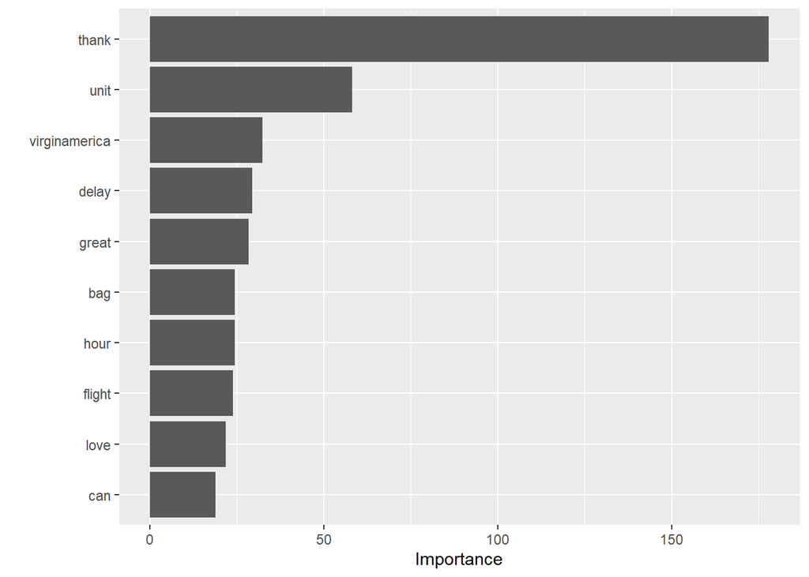

```r
vip(rf)
```

##### A-4. SVM model

```r
#svm모델
set.seed(123)
tune.out = tune(svm, type~., data=train1, kernel="radial",  ranges=list(cost=c(1,10),  gamma=c(0.1,1)), scale=FALSE)
#찾은 파라미터로 모델 재생성
x.svm = svm(type~., data=train1, cost=1, gamma=0.1, probability=TRUE, scale=FALSE)
#cost, gamma결과 확인
summary(tune.out)
```

```
##
## Parameter tuning of 'svm':
##
## - sampling method: 10-fold cross validation
##
## - best parameters:
##  cost gamma
##     1   0.1
##
## - best performance: 0.2832
##
## - Detailed performance results:
##   cost gamma  error dispersion
## 1    1   0.1 0.2832 0.02185203
## 2   10   0.1 0.2850 0.01692467
## 3    1   1.0 0.3194 0.01411225
## 4   10   1.0 0.3198 0.01238099
```

```r
#테스트셋 정확도 확인
pred2 <- predict(x.svm,type="prob", newdata=test1, probability = TRUE)
confusionMatrix(pred2, test$type)
```

```
## Confusion Matrix and Statistics
##
##           Reference
## Prediction negative neutral positive
##   negative     5076     798      409
##   neutral       750    1066      243
##   positive      222     178      898
##
## Overall Statistics
##
##                Accuracy : 0.7303
##                  95% CI : (0.7213, 0.7391)
##     No Information Rate : 0.6274
##     P-Value [Acc > NIR] : < 2.2e-16
##
##                   Kappa : 0.4855
##
##  Mcnemar's Test P-Value : 1.927e-14
##
## Statistics by Class:
##
##                      Class: negative Class: neutral Class: positive
## Sensitivity                   0.8393         0.5220         0.57935
## Specificity                   0.6640         0.8693         0.95056
## Pos Pred Value                0.8079         0.5177         0.69183
## Neg Pred Value                0.7105         0.8713         0.92184
## Prevalence                    0.6274         0.2118         0.16079
## Detection Rate                0.5266         0.1106         0.09315
## Detection Prevalence          0.6518         0.2136         0.13465
## Balanced Accuracy             0.7516         0.6957         0.76496
```

- svm모델을 학습시키는 시간이 한 번 돌릴 때 10분이상 소비되어 다양한 파라미터 튜닝을 하기에는 제한되었다.
- 정확도는 73%가 나왔다.
- cost와 gamma를 각각 1,10 / 0.1,1을 주고 분석한 결과 best parameter는 차례대로 1과 0.1이 나왔다.
- sensitivity를 분석한 결과 대체로 neutral 데이터를 잘 분류해내지 못한다.

##### A-5. 각 모델의 성능 비교 with ROC Curve

```r
#logistic regression ROC curve
multiclass.roc(test$type,prediction2_prob)
```

```
##
## Call:
## multiclass.roc.default(response = test$type, predictor = prediction2_prob)
##
## Data: multivariate predictor prediction2_prob with 3 levels of test$type: positive, negative, neutral.
## Multi-class area under the curve: 0.7611
```

```r
#Random Forest ROC curve
multiclass.roc(test$type,rf_prob)
```

```
##
## Call:
## multiclass.roc.default(response = test$type, predictor = rf_prob)
##
## Data: multivariate predictor rf_prob with 3 levels of test$type: positive, negative, neutral.
## Multi-class area under the curve: 0.834
```

```r
#svm ROC curve
pred3=attr(pred2, "probabilities")
multiclass.roc(test$type,pred3)
```

```
##
## Call:
## multiclass.roc.default(response = test$type, predictor = pred3)
##
## Data: multivariate predictor pred3 with 3 levels of test$type: neutral, positive, negative.
## Multi-class area under the curve: 0.8334
```

##### A-6. DTM을 이용한 모델 분석 결론

[output not shown]

- Logistic 모델에 비해서는 Forest 모델과 svm모델이 결과가 더 좋다.
- svm모델과 FOrest모델은 큰 차이는 없지만 정확도는 조금더 svm모델이 높다.
- 대체적으로 성능의 한계로 parameter tuning을 효과적으로 하지못하여 정확도에 향상에 한계를 보였다.

#### B. TF-IDF을 사용하여 각 모델에 적용한다.

##### B-1. TF-IDF를 이용한 데이터셋 생성

```r
#TF-IDF메트릭스 생성
sent_tfidf <- weightTfIdf(sent_DTM)
#TF-IDF점수에 따라 feature 제거
sent_dfidf <- removeSparseTerms(sent_tfidf, 0.995)
#데이터프레임 생성
sent <- data.frame(as.matrix(sent_dfidf))
#train, test 데이터 셋 생성
colnames(sent) <- make.names(colnames(sent))
sent$type <- data$airline_sentiment
train = sent[1:5000,]
test = sent[5001:14640,]
```

##### B-2. multinomial Logistic Regression

```r
#positive를 기준 변수로 사용
train$type <- relevel(train$type, "positive")
#다항 로지스틱 회귀모델
set.seed(123)
#모델 생성
mlogit = multinom(type~., data=train)
#aic값
mlogit$AIC
```

```
## [1] 6499.054
```

```r
prediction1 = predict(mlogit, newdata = train, "class")
#train table 분류 결과 테이블
ctable1 = table(train$type, prediction1)
ctable1
```

```
##           prediction1
##            positive negative neutral
##   positive      515      201      97
##   negative       80     2834     216
##   neutral        86      399     572
```

```r
#정확도
round((sum(diag(ctable1))/sum(ctable1))*100,2)
```

```
## [1] 78.42
```

- 다항 로지스틱 회귀 결과 train데이터에 대한 정확도는 78.42%가 나왔다.

```r
#test 데이터 확률 및 분류 예측
prediction2_prob=predict(mlogit, newdata = test, "prob")
prediction2 = predict(mlogit, newdata = test, "class")
#test table 분류 결과 테이블
ctable2 = table(test$type, prediction2)
ctable2
```

```
##           prediction2
##            positive negative neutral
##   negative      850     4565     633
##   neutral       351      997     694
##   positive      800      548     202
```

```r
#정확도
round((sum(diag(ctable2))/sum(ctable2))*100,2)
```

```
## [1] 21.26
```

##### B-3. Random Forest

```r
#tree가 50인 포레스트 모델 생성
set.seed(123)
rf <- randomForest(type~., data=train, ntree=50)
#test 데이터 class 예측
rf_pred1 <- predict(rf, newdata=test, type="class")
#test 데이터 분류 매트릭스
confusionMatrix(rf_pred1, test$type, positive = "positive")
```

```
## Confusion Matrix and Statistics
##
##           Reference
## Prediction negative neutral positive
##   negative     5067     845      377
##   neutral       726     975      237
##   positive      255     222      936
##
## Overall Statistics
##
##                Accuracy : 0.7239
##                  95% CI : (0.7148, 0.7328)
##     No Information Rate : 0.6274
##     P-Value [Acc > NIR] : < 2.2e-16
##
##                   Kappa : 0.4736
##
##  Mcnemar's Test P-Value : 3.136e-07
##
## Statistics by Class:
##
##                      Class: negative Class: neutral Class: positive
## Sensitivity                   0.8378         0.4775          0.6039
## Specificity                   0.6598         0.8733          0.9410
## Pos Pred Value                0.8057         0.5031          0.6624
## Neg Pred Value                0.7073         0.8615          0.9254
## Prevalence                    0.6274         0.2118          0.1608
## Detection Rate                0.5256         0.1011          0.0971
## Detection Prevalence          0.6524         0.2010          0.1466
## Balanced Accuracy             0.7488         0.6754          0.7725
```

- 튜닝을 하지 않은 랜덤포레스트 모델의 test데이터 정확도는 72.39%이다.
- 정확도가 어느정도 높은것으로 볼 때 파라미터 튜닝을 한다면 더 높은 정확도를 보일 것이다.
- mtry를 조정하여 feature의수를 조정하는대신 전처리 과정에서 feature수를 조정하였다.

```r
set.seed(123)
#트리의 수를 6배 늘려 randomforest실행
rf <- randomForest(type~., data=train, ntree=300)
#test 데이터 값 예측
rf_prob <- predict(rf, newdata=test, type="prob")
rf_pred1 <- predict(rf, newdata=test, type="class")
#test 데이터 분류 매트릭스
confusionMatrix(rf_pred1, test$type, positive = "positive")
```

```
## Confusion Matrix and Statistics
##
##           Reference
## Prediction negative neutral positive
##   negative     4993     795      352
##   neutral       804    1034      248
##   positive      251     213      950
##
## Overall Statistics
##
##                Accuracy : 0.7238
##                  95% CI : (0.7147, 0.7327)
##     No Information Rate : 0.6274
##     P-Value [Acc > NIR] : < 2.2e-16
##
##                   Kappa : 0.4797
##
##  Mcnemar's Test P-Value : 0.000203
##
## Statistics by Class:
##
##                      Class: negative Class: neutral Class: positive
## Sensitivity                   0.8256         0.5064         0.61290
## Specificity                   0.6807         0.8615         0.94265
## Pos Pred Value                0.8132         0.4957         0.67185
## Neg Pred Value                0.6986         0.8666         0.92706
## Prevalence                    0.6274         0.2118         0.16079
## Detection Rate                0.5179         0.1073         0.09855
## Detection Prevalence          0.6369         0.2164         0.14668
## Balanced Accuracy             0.7531         0.6840         0.77777
```

- tree의 수를 증가시켰지만 test셋에 대한 정확도는 72.39%로 크게 차이가 나지 않는다.
- DTM과 비교하여 크게 정확도가 향상되지는 않았다.

```r
#MAE와 영향을 미치는 feature 탐색
MAE(as.numeric(rf_pred1), as.numeric(test$type))
```

```
## [1] 1.047718
```

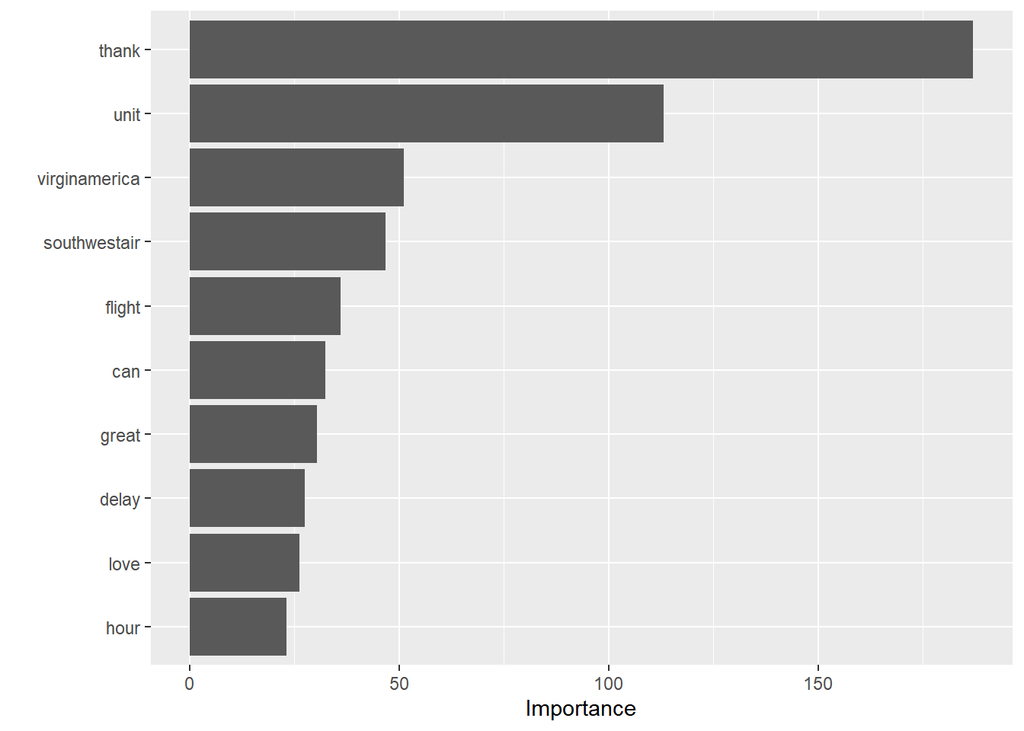

```r
vip(rf)
```

##### B-4. SVM model

```r
#svm모델, kernel은 가장효과가 좋은 RBF kernel 사용
set.seed(123)
tune.out = tune(svm, type~., data=train, kernel="radial",  ranges=list(cost=c(1,10),  gamma=c(0.1,1)), scale=FALSE)
#cost, gamma결과 확인
summary(tune.out)
```

```
##
## Parameter tuning of 'svm':
##
## - sampling method: 10-fold cross validation
##
## - best parameters:
##  cost gamma
##    10   0.1
##
## - best performance: 0.2644
##
## - Detailed performance results:
##   cost gamma  error dispersion
## 1    1   0.1 0.2776 0.02092951
## 2   10   0.1 0.2644 0.01680741
## 3    1   1.0 0.2956 0.01892206
## 4   10   1.0 0.2984 0.02212691
```

```r
#찾은 파라미터로 모델 재생성
x.svm = svm(type~., data=train, cost=10, gamma=0.1, probability=TRUE, scale=FALSE)
#테스트셋 정확도 확인
pred2 <- predict(x.svm,type="prob", newdata=test, probability = TRUE)
confusionMatrix(pred2, test$type)
```

```
## Confusion Matrix and Statistics
##
##           Reference
## Prediction negative neutral positive
##   negative     5575    1183      601
##   neutral       335     651      109
##   positive      138     208      840
##
## Overall Statistics
##
##                Accuracy : 0.733
##                  95% CI : (0.724, 0.7418)
##     No Information Rate : 0.6274
##     P-Value [Acc > NIR] : < 2.2e-16
##
##                   Kappa : 0.4405
##
##  Mcnemar's Test P-Value : < 2.2e-16
##
## Statistics by Class:
##
##                      Class: negative Class: neutral Class: positive
## Sensitivity                   0.9218        0.31881         0.54194
## Specificity                   0.5033        0.94156         0.95723
## Pos Pred Value                0.7576        0.59452         0.70826
## Neg Pred Value                0.7926        0.83721         0.91602
## Prevalence                    0.6274        0.21183         0.16079
## Detection Rate                0.5783        0.06753         0.08714
## Detection Prevalence          0.7634        0.11359         0.12303
## Balanced Accuracy             0.7126        0.63018         0.74958
```

- svm 모델 학습 시간이 상당히 오래걸려 제한된 parameter로 튜닝하였다.
- cost와 gamma를 각각 1,10 / 0.1,1을 주고 분석한 결과 best parameter는 차례대로 10과 0.1이 나왔다.
- 정확도는 73%가 나왔다.
- sensitivity를 분석한 결과 대체로 neutral 데이터를 잘 분류해내지 못한다.
- DTM과 비교하여 크게 성능이 증가하지는 않았다.

##### B-5. 각 모델의 성능 비교 with ROC Curve

```r
#logistic regression ROC curve
multiclass.roc(test$type,prediction2_prob)
```

```
##
## Call:
## multiclass.roc.default(response = test$type, predictor = prediction2_prob)
##
## Data: multivariate predictor prediction2_prob with 3 levels of test$type: positive, negative, neutral.
## Multi-class area under the curve: 0.7323
```

```r
#Random Forest ROC curve
multiclass.roc(test$type,rf_prob)
```

```
##
## Call:
## multiclass.roc.default(response = test$type, predictor = rf_prob)
##
## Data: multivariate predictor rf_prob with 3 levels of test$type: positive, negative, neutral.
## Multi-class area under the curve: 0.8277
```

```r
#svm ROC curve
pred3=attr(pred2, "probabilities")
multiclass.roc(test$type,pred3)
```

```
##
## Call:
## multiclass.roc.default(response = test$type, predictor = pred3)
##
## Data: multivariate predictor pred3 with 3 levels of test$type: neutral, positive, negative.
## Multi-class area under the curve: 0.8287
```

##### B-6. TF-IDF을 이용한 모델 분석 결론

[output not shown]

- DTM을 사용했을 때와 모델의 성능이 크게 차이나지 않았다.

### 4. 전체 결론

- **최종적으로 선택한 모델은 SVM모델이며 test set에 대한 정확도는 73%이다.**
- **전체 모델은 대체적으로 neutral 데이터와 positive데이터를 잘 분류해내지 못하였으며 특히 neutral데이터를 잘 분류해내지 못하였다. 부정과 긍정은 단어의 특색이 뚜렸히 들어나는 것에 비해 중립은 그렇지 않기 때문에 나타나는 결과로 보이며 data자체의 양이 negative 데이터에 집중되어있어 negative분류 결과 좋은것으로 고려된다.**
- **데이터 수를 더 늘리고 input데이터의 라벨링 분포가 더 고르게 되어있었다면 훨씬 좋은 정확도가 측정되었을 것이라고 생각된다.**
- Logistic regression, RandomForest, SVM모델을 이용하여 분석을 실시한 결과 비교적 Random Forest 모델과 SVM모델의 정확도가 높게 형성되었다.
- Random Forest모델과 Svm모델은 parameter 값에 따라 성능이 좌우지 될 수 있는 모델이지만 상황적 한계로 충실히 이행하지 못하였다.